[interactive chart not shown]

# Association Rule Mining - (Frequently Purchased Items in Groups Prediction)

#### **Instructor:** [Vijay Gurbani (Chief Data Scientist at Vail Systems, Inc)](https://youtu.be/8oDjrAknr4o?t=11)

#### **Project Summary**

- Analyzed a bakery dataset using the Apriori algorithm to uncover associations between frequently purchased items.
- Processed transaction data to generate frequent itemsets and rules that help understand customer purchasing behavior.
- Utilized association rule mining to identify relationships and patterns between different bakery products.
- Generated rules based on support, confidence, and lift metrics to identify strong associations and their reliability in predicting item combinations.

#### **About the Dataset**

This dataset contains transactions from a bakery, with various numbers of transactions, including 1,000 to 75,000. Each transaction lists the items purchased by a customer during their visit. Key attributes include product names and transaction IDs, with the goal of identifying frequent itemsets and association rules that capture the relationship between products purchased together.

#### **Libraries Used:** arules, arulesViz, ggplot2

#### **Key Findings**

The analysis of various datasets revealed consistent patterns in customer purchasing habits, with frequent itemsets such as {Hot Coffee}, {Coffee Eclair}, {Raspberry Lemonade}, {Raspberry Cookie}, and {Lemon Cookie} standing out. Strong associations between these and other items suggest valuable opportunities for bundling, cross-selling, and targeted promotions to enhance customer experience and drive sales.

#### **Data Visualizations**

Scatter plots and bar charts were used to visualize the support and confidence of various rules, making it easier to interpret the frequent itemsets and their corresponding relationships. A graphical representation of the rules provided a clear overview of the most significant product combinations.

#### **Conclusions**

This project highlights my ability to apply the Apriori algorithm for association rule mining in real-world datasets. The insights gained from frequent itemsets and strong rules demonstrate how data mining techniques can be used to enhance marketing strategies, optimize inventory, and improve customer experience in various environments.

Associate Rule Mining

- Return to projects

Sections

- 1,000 Transactions Dataset
- 5,000 Transactions Dataset
- 20,000 Transactions Dataset
- 75,000 Transactions Dataset
- Final Conclusions

#### What is associate rule mining?

Association rule mining is a data analysis technique that helps uncover patterns and relationships between items in large datasets. It’s commonly used in retail to discover which items are frequently bought together. The Apriori algorithm is a popular tool for this task, as it identifies frequent itemsets based on how often they appear together and creates rules to predict future purchases. For example, if many people buy cookies and coffee together, the algorithm can suggest that customers who buy cookies are also likely to buy coffee. This helps businesses optimize product placement, create bundles, and design targeted promotions.

### 1,000 Transactions Dataset

I began this project by analyzing a dataset of 1,000 transactions using the `read.transactions` function and applying the `apriori` algorithm to identify frequent itemsets. With a minimum support of 0.01 (1%) and a support count threshold of 10 (meaning an itemset had to appear in at least 10 transactions, which is 1% of the total transactions), I identified 132 frequent itemsets, revealing key insights into item relationships and filtering out less common combinations.

Note: In the section covering the 1,000 transactions dataset, I provided a detailed explanation of how the plots work and the key features of the Apriori algorithm, including support, confidence, and lift. I recommend reviewing this section first, as it covers the foundational concepts that will help you better understand the analysis of the larger datasets.

**Why is 1% Considered Frequent?**

In the context of data mining, "frequent" does not always imply a high percentage of occurrences across the entire dataset. A minimum support threshold of 1% means that an itemset must appear in at least 1% of the transactions to be considered frequent. This might seem low, but in large datasets with thousands or millions of transactions, even a 1% occurrence can represent a significant number of transactions. Frequent patterns help identify meaningful relationships between items that occur often enough to be considered relevant for analysis or decision-making, even at a seemingly small percentage.

```r
library(arules)
library(arulesViz)
library(ggplot2)

working_directory <- getwd()
set_working_directory <- working_directory
```

```r
tr1k <- read.transactions("tr-1k-canonical.csv", sep = ",")
frequent_item_sets_tr1k <- apriori(tr1k, parameter = list(support = 0.01, target = "frequent itemsets"))
```

```
Apriori

Parameter specification:
```

|  | confidence | minval | smax | arem | aval | originalSupport | maxtime | support | minlen | maxlen | target | ext |
| --- | --- | --- | --- | --- | --- | --- | --- | --- | --- | --- | --- | --- |
|  | NA | 0.1 | 1 | none | FALSE | TRUE | 5 | 0.01 | 1 | 10 | frequent itemsets | TRUE |

```
Algorithmic control:
```

|  | filter | tree | heap | memopt | load | sort | verbose |
| --- | --- | --- | --- | --- | --- | --- | --- |
|  | 0.1 | TRUE | TRUE | FALSE | TRUE | 2 | TRUE |

```
Absolute minimum support count: 10

set item appearances ...[0 item(s)] done [0.00s].
set transactions ...[50 item(s), 1000 transaction(s)] done [0.01s].
sorting and recoding items ... [50 item(s)] done [0.00s].
creating transaction tree ... done [0.00s].
checking subsets of size 1 2 3 4 5 done [0.00s].
sorting transactions ... done [0.00s].
writing ... [132 set(s)] done [0.00s].
creating S4 object  ... done [0.00s].
```

## Frequent Itemsets Analysis

After generating the frequent itemsets using the Apriori algorithm on the Tr1k dataset, we identified combinations of items that co-occur in at least 1% of the 1,000 transactions. These frequent itemsets provide valuable insights into common item groupings, which can be useful for understanding purchasing behaviors or identifying related products.

#### Frequent Itemsets - Examples

Here are two examples of frequent itemsets identified in the Tr1k dataset:

- **Itemset:** {Gongolais Cookie}, **Support:** 10.8%, **Count:** 108 transactions
- **Itemset:** {Truffle Cake}, **Support:** 10.3%, **Count:** 103 transactions

These itemsets occur frequently across the dataset, indicating that these items are commonly purchased together or individually, providing useful information about customer preferences.

Note: To see the support and count for each item, click the arrow on the item row to shift the row and reveal the details.

#### Understanding Support and Count

**Support** reflects how often an item or itemset appears in the dataset as a percentage of total transactions. For instance, a support value of 10.8% for {Gongolais Cookie} means it appears in 10.8% of all transactions. Support is a crucial measure for identifying frequently occurring itemsets.

**Count** is the actual number of transactions that include the specific item or itemset. For example, the count for {Gongolais Cookie} is 108, meaning it appears in 108 out of 1,000 transactions. The count provides a concrete, numerical representation of how often an itemset is seen in the dataset.

By understanding both support and count, we can better evaluate the significance of different itemsets in the transaction dataset, helping to inform decisions based on purchasing trends.

```r
print(inspect(sort(frequent_item_sets_tr1k, decreasing = T, by="count")))
```

|  | items | support | count |
| --- | --- | --- | --- |
| [1] | {Gongolais Cookie} | 0.108 | 108 |
| [2] | {Truffle Cake} | 0.103 | 103 |
| [3] | {Tuile Cookie} | 0.102 | 102 |
| [4] | {Berry Tart} | 0.095 | 95 |
| [5] | {Hot Coffee} | 0.094 | 94 |
| [6] | {Coffee Eclair} | 0.093 | 93 |
| [7] | {Strawberry Cake} | 0.091 | 91 |
| [8] | {Apple Croissant} | 0.091 | 91 |
| [9] | {Marzipan Cookie} | 0.090 | 90 |
| [10] | {Napoleon Cake} | 0.090 | 90 |

[output cut: 122 more lines]

```r
frequent_item_sets <- sort(frequent_item_sets_tr1k, decreasing = TRUE, by = "count")


frequent_itemsets_df <- as(frequent_item_sets, "data.frame")


top_frequent_itemsets <- head(frequent_itemsets_df, 10)


ggplot(top_frequent_itemsets, aes(x = reorder(items, count), y = count)) +
  geom_bar(stat = "identity", fill = "steelblue") +
  coord_flip() +
  labs(title = "Top 10 Frequent Itemsets in 1,000 Transactions", x = "Itemsets", y = "Count") +
  theme_minimal()
```

#### Summary of Top 10 Frequent Itemsets in 1,000 Transactions

This chart shows the top 10 frequent itemsets in 1,000 transactions, with cookies, and cakes dominating the list. Popular items include Gongolais Cookie, Truffle Cake, Tuile Cookie, and Hot Coffee, across more than 90 transactions. These findings could suggest a strong customer preference for baked goods and coffee, which could be leveraged for bundling and promotional strategies to increase sales.

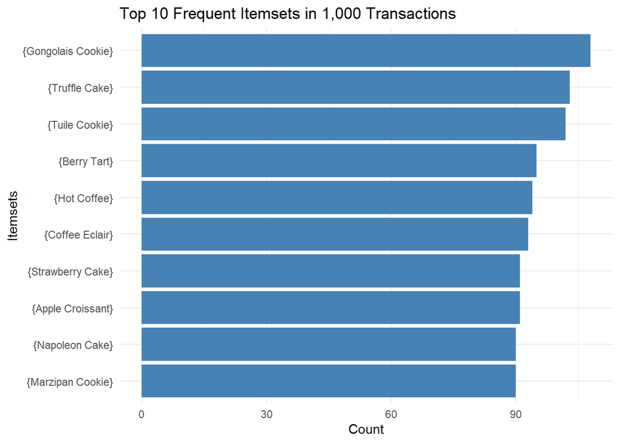

#### Generating Association Rules with Apriori

I also used the `apriori` algorithm on the 1,000 transactions dataset, to discover patterns between items. The algorithm was set to focus on itemsets that appeared in at least 1% of the transactions and only considered rules with a confidence level of 85% or higher (meaning that when one item is bought, there's an 85% chance the associated item will also be purchased). This helped reveal strong relationships between frequently bought items that met these criteria.

```r
rules_for_tr1k <- apriori(tr1k, parameter = list(support = 0.01, conf = 0.85, target = "rules"))
```

```
Apriori

Parameter specification:
```

|  | confidence | minval | smax | arem | aval | originalSupport | maxtime | support | minlen | maxlen | target | ext |
| --- | --- | --- | --- | --- | --- | --- | --- | --- | --- | --- | --- | --- |
|  | 0.85 | 0.1 | 1 | none | FALSE | TRUE | 5 | 0.01 | 1 | 10 | rules | TRUE |

```
Algorithmic control:
```

|  | filter | tree | heap | memopt | load | sort | verbose |
| --- | --- | --- | --- | --- | --- | --- | --- |
|  | 0.1 | TRUE | TRUE | FALSE | TRUE | 2 | TRUE |

```
Absolute minimum support count: 10

set item appearances ...[0 item(s)] done [0.00s].
set transactions ...[50 item(s), 1000 transaction(s)] done [0.00s].
sorting and recoding items ... [50 item(s)] done [0.00s].
creating transaction tree ... done [0.00s].
checking subsets of size 1 2 3 4 5 done [0.01s].
writing ... [72 rule(s)] done [0.00s].
creating S4 object  ... done [0.00s].
```

## Association Rules Analysis

After generating association rules with the Apriori algorithm on the Tr1k dataset, I identified patterns where the left-hand side (LHS) shows the items a customer buys ("if"), and the right-hand side (RHS) predicts what they are likely to buy next ("then"). These rules reveal how items are commonly purchased together, providing insights into customer behavior.

#### Association Rules - Examples

Here are two examples of association rules identified in the Tr1k dataset:

- **Rule 1:** LHS: {Chocolate Tart, Walnut Cookie} → RHS: {Vanilla Frappuccino}, **Support:** 1.8%, **Confidence:** 1.0, **Lift:** 13.51, **Count:** 18 transactions

If a customer buys both a Chocolate Tart and a Walnut Cookie, then they are likely to buy a Vanilla Frappuccino.

- **Rule 2:** LHS: {Apricot Croissant, Hot Coffee} → RHS: {Blueberry Tart}, **Support:** 3.2%, **Confidence:** 1.0, **Lift:** 12.34, **Count:** 32 transactions

If a customer buys both an Apricot Croissant and a Hot Coffee, then they are likely to buy a Blueberry Tart.

These association rules illustrate how certain items are frequently purchased together, providing valuable insights into potential bundling or product recommendation strategies.

#### Understanding Support, Confidence, Lift, and Count

**Support:** This represents the proportion of transactions that include both the LHS and RHS items. For example, a support value of 1.8% means the rule occurs in 1.8% of all transactions.

**Confidence:** The probability that the RHS item will be purchased when the LHS items are bought. A confidence of 1.0 means the rule holds 100% of the time.

**Lift:** This measures how much more likely the RHS item is to be bought when the LHS items are purchased, compared to random chance. A lift greater than 1 indicates a strong association.

**Count:** The number of transactions where both the LHS and RHS items occur together, providing an absolute number of occurrences.

```r
print(inspect(sort(rules_for_tr1k, by="confidence")))
```

|  | lhs |  | rhs | support | confidence | coverage | lift | count |
| --- | --- | --- | --- | --- | --- | --- | --- | --- |
| [1] | {Chocolate Tart, Walnut Cookie} | => | {Vanilla Frappuccino} | 0.018 | 1.0000000 | 0.018 | 13.513514 | 18 |
| [2] | {Vanilla Frappuccino, Walnut Cookie} | => | {Chocolate Tart} | 0.018 | 1.0000000 | 0.018 | 19.607843 | 18 |
| [3] | {Apricot Croissant, Hot Coffee} | => | {Blueberry Tart} | 0.032 | 1.0000000 | 0.032 | 12.345679 | 32 |
| [4] | {Raspberry Cookie, Raspberry Lemonade} | => | {Lemon Cookie} | 0.029 | 1.0000000 | 0.029 | 15.151515 | 29 |
| [5] | {Green Tea, Lemon Cookie, Lemon Lemonade} | => | {Raspberry Lemonade} | 0.019 | 1.0000000 | 0.019 | 13.888889 | 19 |
| [6] | {Green Tea, Lemon Lemonade, Raspberry Lemonade} | => | {Lemon Cookie} | 0.019 | 1.0000000 | 0.019 | 15.151515 | 19 |
| [7] | {Green Tea, Lemon Cookie, Raspberry Lemonade} | => | {Lemon Lemonade} | 0.019 | 1.0000000 | 0.019 | 15.151515 | 19 |
| [8] | {Green Tea, Lemon Cookie, Lemon Lemonade} | => | {Raspberry Cookie} | 0.019 | 1.0000000 | 0.019 | 12.195122 | 19 |
| [9] | {Green Tea, Lemon Lemonade, Raspberry Cookie} | => | {Lemon Cookie} | 0.019 | 1.0000000 | 0.019 | 15.151515 | 19 |
| [10] | {Green Tea, Lemon Cookie, Raspberry Cookie} | => | {Lemon Lemonade} | 0.019 | 1.0000000 | 0.019 | 15.151515 | 19 |

[output cut: 62 more lines]

## Rules visualizations

In the following section, we’ll explore key insights through visualizations of the association rules, using plots to highlight patterns and relationships between frequently purchased items.

```r
rules_sorted <- sort(rules_for_tr1k, by = "confidence", decreasing = TRUE)

# Count the number of rules
number_of_rules <- length(rules_for_tr1k)
print(paste("Number of rules:", number_of_rules))
```

```r
## [1] "Number of rules: 72"
```

```r
# Create a parallel coordinates plot for clearer visualization
plot(rules_sorted,
     method = "paracoord",
     control = list(reorder = TRUE),
     main = "Parallel Coordinates Plot of High-Confidence Rules")
```

#### Understanding the Parallel Coordinates Plot

In this plot, the **arrows** represent relationships between items that are often purchased together. Each arrow connects the left-hand side (lhs) items (e.g., a cookie or a coffee) to the right-hand side (rhs) items (e.g., another drink or dessert). Each arrow represents a separate rule. For example, by following the beginning of an arrow, you can see the position and name of the item in the rule. Some rules might have three items, and when you follow the arrow to its end, you will see the rhs item (the item that the customer is likely to buy).

**Thickness of the Arrow (Support):**

The thickness of an arrow shows how often these items are bought together. This is called *support*. For example, if many customers frequently buy a *Walnut Cookie* with a *Vanilla Frappuccino*, the arrow connecting these two items will be thick. In simple terms, support tells us the popularity of the combination — the thicker the arrow, the more often the combination appears in transactions.

**Color Intensity (Confidence):**

The intensity of the arrow’s color shows how *confident* we are that if a customer buys one item, they are likely to buy the other. This is called *confidence*. A deeper red arrow means a high confidence level — meaning, if someone buys a *Chocolate Tart*, they are very likely to also buy a *Cherry Soda*. In simple terms, confidence tells us how strong the link is between two items.

#### Example:

Let’s say there’s a thick, dark red arrow between *Apple Pie* and *Hot Coffee*. This means:

- **Support** (thick arrow): Many people buy *Apple Pie* and *Hot Coffee* together.
- **Confidence** (dark red color): If someone buys *Apple Pie*, there's a high chance they'll also buy *Hot Coffee*.

This insight helps us understand common purchasing habits and can be used to make product recommendations or plan promotions based on what customers are likely to buy together.

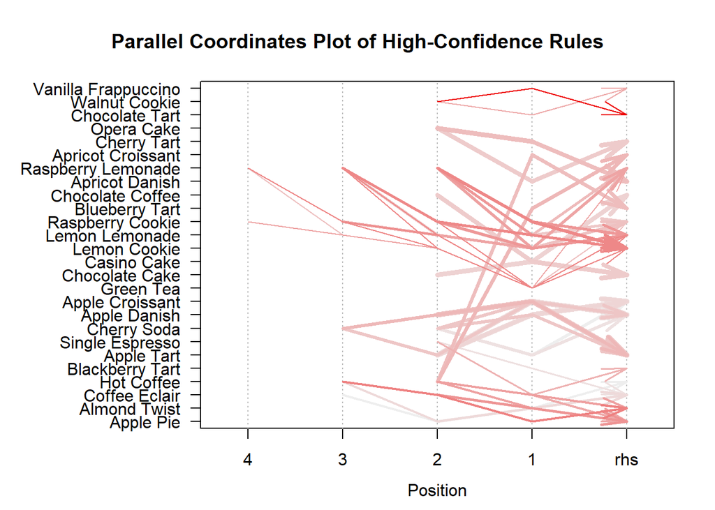

#### Key Insights from the Parallel Coordinates Plot of High-Confidence Rules

This plot reveals strong associations between frequently purchased items, particularly bakery products and beverages. Items such as Raspberry Cookie, Blueberry Tart, Lemon Lemonade, Lemon Cookie, and Raspberry Lemonade often appear together, suggesting great opportunities for bundling and targeted promotions. Walnut Cookie and Vanilla Frappuccino also show a high confidence when paired, indicating a reliable pattern. Some groupings are represented by thick arrows, which highlight their popularity, though they may have lower confidence levels due to their low color intensity. By strategically promoting or placing these combinations, businesses can boost sales and enhance the customer experience.

#### Interpretation of the Graph

This plot visualizes **association rules** between frequently purchased items, where the items on the **left-hand side (LHS)** are associated with items on the **right-hand side (RHS)**.

#### Key Elements:

**Bubbles**: Each bubble represents an association rule. The size of the bubble indicates the **support** (how often the items are bought together), and the color shows the **confidence** (the likelihood that the RHS item will be purchased if the LHS items are).

- **Larger bubbles**: These indicate that the items are frequently purchased together (higher support).
- **Darker red bubbles**: These represent higher confidence, meaning if you buy the items on the LHS, you’re very likely to buy the RHS item.
- **Lighter red bubbles**: These have lower confidence, indicating a weaker relationship between the LHS and RHS items.

#### Example Analysis:

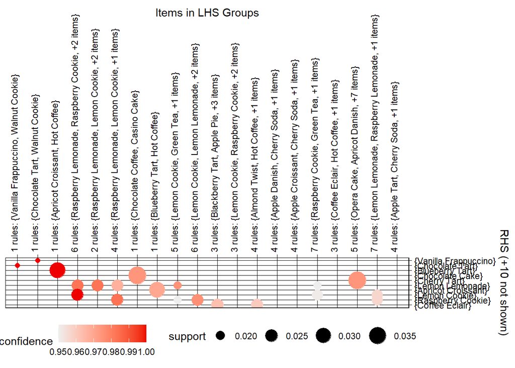

```r
# Create a grouped matrix plot to visualize the association rules
plot(rules_for_tr1k,
     method = "grouped",
     measure = "support",
     shading = "confidence",
     main = "Grouped Matrix of Association Rules")
```

#### Analysis of Specific Associations:

##### Low-Confidence Associations:

Some rules with lighter-colored bubbles, such as those involving **Apple Croissant and Cherry Soda**, show lower confidence despite their moderate support. These rules indicate weaker relationships between the items on the LHS and RHS, suggesting that while they occur somewhat frequently, the purchase of the RHS item is less certain when the LHS items are bought together.

#### Strategic Implications:

**Bundling Opportunities:** High-confidence rules with strong support are prime candidates for product bundling or cross-selling. For example, promotions involving **Hot Coffee, Apricot Croissant, Raspberry Lemonade, Lemon Cookie**, and **Raspberry Lemonade**, could entice more customers to make a purchase.

**Marketing Adjustments:** Items with lower support but high confidence, such as **Vanilla Frappuccino and Walnut Cookie**, could be featured in targeted campaigns to boost sales of less frequent, but strongly correlated, combinations.

#### Interpretation of the Scatter Plot by Support and Confidence

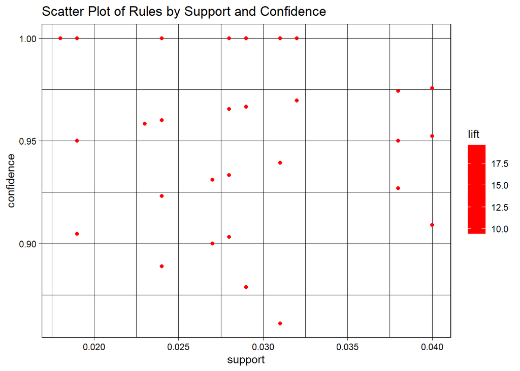

```r
# Create a scatter plot with support on the x-axis and confidence on the y-axis
# Color by lift and size by lift for better distinction
plot(rules_sorted,
     method = "scatterplot",
     measure = c("support", "confidence"),
     shading = "lift",
     control = list(col = rev(heat.colors(100))),
     main = "Scatter Plot of Rules by Support and Confidence",
     jitter = 0)  # Jitter set to zero to avoid overlapping
```

### 5,000 Transactions Dataset

The Apriori algorithm identified frequent itemsets with an absolute minimum support count of 50, meaning that only itemsets appearing in at least 50 transactions were included. A total of 50 unique items were processed across 5,000 transactions, and 124 frequent itemsets were generated. The algorithm efficiently sorted and recoded the items, created a transaction tree, and analyzed subsets of size 1 to 5, ensuring accurate and timely results.

```r
tr5k <- read.transactions("tr-5k-canonical.csv", sep = ",")
frequent_item_sets_tr5k <- apriori(tr5k, parameter = list(support = 0.01, target = "frequent itemsets"))
```

```
Apriori

Parameter specification:
```

|  | confidence | minval | smax | arem | aval | originalSupport | maxtime | support | minlen | maxlen | target | ext |
| --- | --- | --- | --- | --- | --- | --- | --- | --- | --- | --- | --- | --- |
|  | NA | 0.1 | 1 | none | FALSE | TRUE | 5 | 0.01 | 1 | 10 | frequent itemsets | TRUE |

```
Algorithmic control:
```

|  | filter | tree | heap | memopt | load | sort | verbose |
| --- | --- | --- | --- | --- | --- | --- | --- |
|  | 0.1 | TRUE | TRUE | FALSE | TRUE | 2 | TRUE |

```
Absolute minimum support count: 50

set item appearances ...[0 item(s)] done [0.00s].
set transactions ...[50 item(s), 5000 transaction(s)] done [0.01s].
sorting and recoding items ... [50 item(s)] done [0.00s].
creating transaction tree ... done [0.00s].
checking subsets of size 1 2 3 4 5 done [0.01s].
sorting transactions ... done [0.00s].
writing ... [124 set(s)] done [0.00s].
creating S4 object  ... done [0.00s].
```

## Frequent Itemsets Analysis

```r
print(inspect(sort(frequent_item_sets_tr5k, decreasing = T, by="count")))
```

|  | items | support | count |
| --- | --- | --- | --- |
| [1] | {Coffee Eclair} | 0.1108 | 554 |
| [2] | {Hot Coffee} | 0.1026 | 513 |
| [3] | {Tuile Cookie} | 0.0998 | 499 |
| [4] | {Strawberry Cake} | 0.0960 | 480 |
| [5] | {Gongolais Cookie} | 0.0954 | 477 |
| [6] | {Orange Juice} | 0.0922 | 461 |
| [7] | {Cherry Tart} | 0.0920 | 460 |
| [8] | {Apricot Danish} | 0.0892 | 446 |
| [9] | {Truffle Cake} | 0.0876 | 438 |
| [10] | {Blueberry Tart} | 0.0852 | 426 |

[output cut: 114 more lines]

```r
# Convert frequent itemsets to a data frame
frequent_itemsets_df <- as(frequent_item_sets_tr5k, "data.frame")

# Select the top 10 frequent itemsets
top_frequent_itemsets <- head(frequent_itemsets_df, 10)

# Create a bar plot for the top frequent itemsets
ggplot(top_frequent_itemsets, aes(x = reorder(items, count), y = count)) +
  geom_bar(stat = "identity", fill = "steelblue") +
  coord_flip() +  # Flip the axes to make it more readable
  labs(title = "Top 10 Frequent Itemsets in 5,000 Transactions", x = "Itemsets", y = "Count") +
  theme_minimal()
```

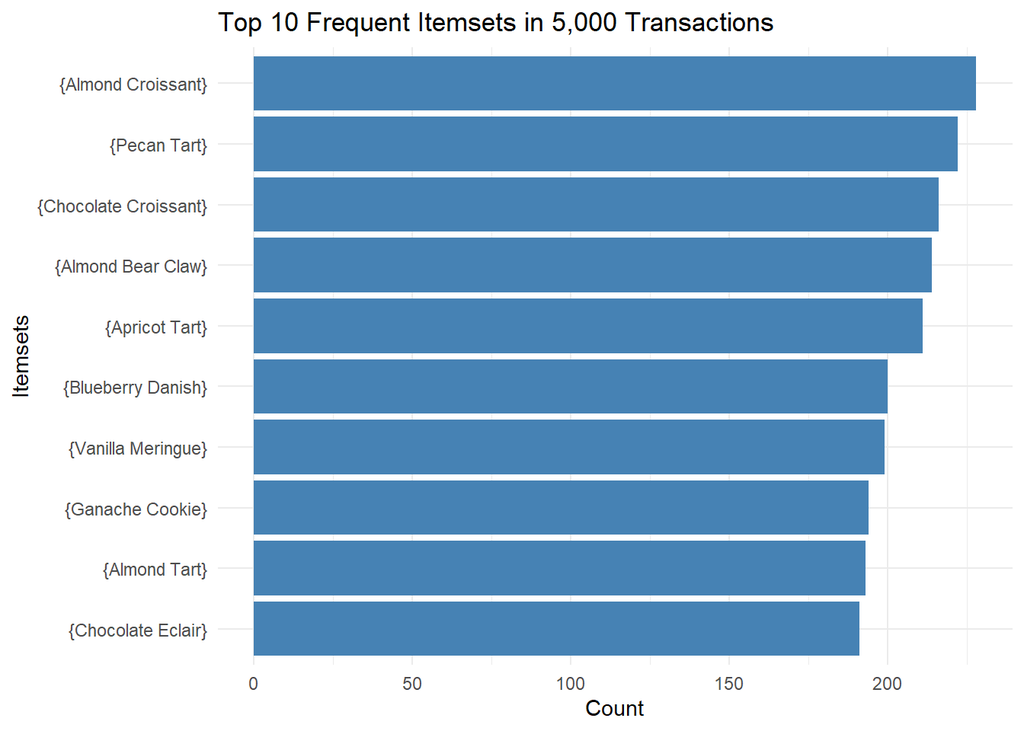

## Association Rules Analysis

After processing the transactions, the Apriori algorithm generated a total of 78 association rules. The absolute minimum support count was set to 50, ensuring that only itemsets appearing in at least 50 transactions were considered. The algorithm efficiently processed 50 unique items across 5,000 transactions, creating a transaction tree and checking item subsets to identify meaningful patterns. The final output included 78 rules, ready for further analysis.

```r
rules_for_tr5k <- apriori(tr5k, parameter = list(support = 0.01,conf = 0.85, target = "rules"))
```

```
Apriori

Parameter specification:
```

|  | confidence | minval | smax | arem | aval | originalSupport | maxtime | support | minlen | maxlen | target | ext |
| --- | --- | --- | --- | --- | --- | --- | --- | --- | --- | --- | --- | --- |
|  | 0.85 | 0.1 | 1 | none | FALSE | TRUE | 5 | 0.01 | 1 | 10 | rules | TRUE |

```
Algorithmic control:
```

|  | filter | tree | heap | memopt | load | sort | verbose |
| --- | --- | --- | --- | --- | --- | --- | --- |
|  | 0.1 | TRUE | TRUE | FALSE | TRUE | 2 | TRUE |

```
Absolute minimum support count: 50

set item appearances ...[0 item(s)] done [0.00s].
set transactions ...[50 item(s), 5000 transaction(s)] done [0.01s].
sorting and recoding items ... [50 item(s)] done [0.00s].
creating transaction tree ... done [0.00s].
checking subsets of size 1 2 3 4 5 done [0.01s].
writing ... [78 rule(s)] done [0.00s].
creating S4 object  ... done [0.00s].
```

```r
print(inspect(sort(rules_for_tr5k, by="confidence")))
```

|  | lhs |  | rhs | support | confidence | coverage | lift | count |
| --- | --- | --- | --- | --- | --- | --- | --- | --- |
| [1] | {Apple Danish, Apple Tart, Cherry Soda} | => | {Apple Croissant} | 0.0228 | 1.0000000 | 0.0228 | 13.477089 | 114 |
| [2] | {Green Tea, Lemon Lemonade, Raspberry Cookie} | => | {Lemon Cookie} | 0.0212 | 1.0000000 | 0.0212 | 15.576324 | 106 |
| [3] | {Green Tea, Lemon Lemonade, Raspberry Cookie} | => | {Raspberry Lemonade} | 0.0212 | 1.0000000 | 0.0212 | 14.749263 | 106 |
| [4] | {Green Tea, Lemon Lemonade, Raspberry Lemonade} | => | {Raspberry Cookie} | 0.0212 | 1.0000000 | 0.0212 | 15.625000 | 106 |
| [5] | {Green Tea, Raspberry Cookie, Raspberry Lemonade} | => | {Lemon Lemonade} | 0.0212 | 1.0000000 | 0.0212 | 15.432099 | 106 |
| [6] | {Green Tea, Lemon Lemonade, Raspberry Lemonade} | => | {Lemon Cookie} | 0.0212 | 1.0000000 | 0.0212 | 15.576324 | 106 |
| [7] | {Green Tea, Lemon Cookie, Raspberry Lemonade} | => | {Lemon Lemonade} | 0.0212 | 1.0000000 | 0.0212 | 15.432099 | 106 |
| [8] | {Green Tea, Raspberry Cookie, Raspberry Lemonade} | => | {Lemon Cookie} | 0.0212 | 1.0000000 | 0.0212 | 15.576324 | 106 |
| [9] | {Green Tea, Lemon Cookie, Raspberry Lemonade} | => | {Raspberry Cookie} | 0.0212 | 1.0000000 | 0.0212 | 15.625000 | 106 |
| [10] | {Lemon Lemonade, Raspberry Cookie, Raspberry Lemonade} | => | {Lemon Cookie} | 0.0262 | 1.0000000 | 0.0262 | 15.576324 | 131 |

[output cut: 68 more lines]

```r
# Count the number of rules
number_of_rules <- length(rules_for_tr5k)
print(paste("Number of rules:", number_of_rules))
```

```
## [1] "Number of rules: 78"
```

```r
# Sort the rules by confidence
rules_sorted <- sort(rules_for_tr5k, by = "confidence", decreasing = TRUE)


# Create a scatter plot of rules with support on x-axis and confidence on y-axis
plot(rules_sorted,
     method = "scatterplot",
     measure = c("support", "confidence"),
     shading = "lift",  # Use lift as the color shading
     control = list(col = rev(heat.colors(100)), jitter = 0),  # Disable jitter
     main = "Scatter Plot of Rules (Support vs Confidence) - Tr5k")  # Set title directly
```

#### Key Insights from Scatter Plot of Rules (Support vs Confidence)

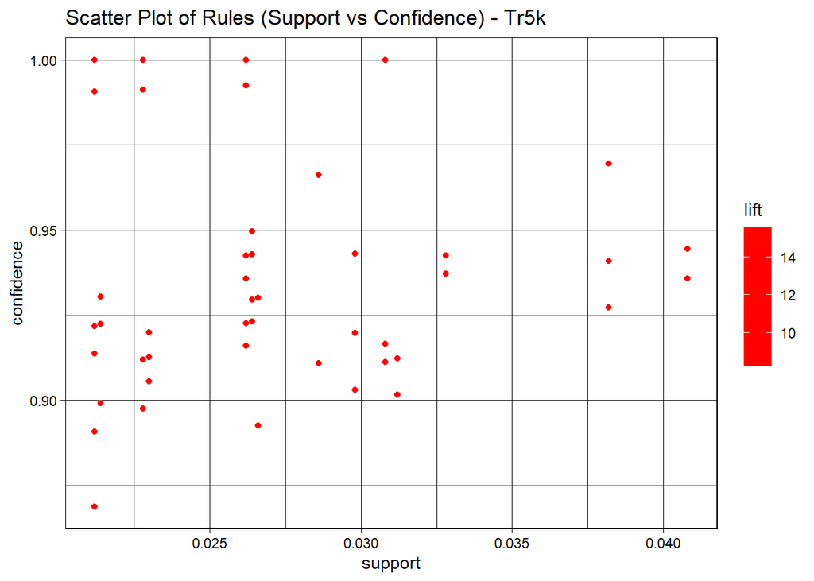

```r
# Create a grouped matrix plot to visualize the association rules
plot(rules_for_tr5k,
     method = "grouped",
     measure = "support",
     shading = "confidence",
     main = "Grouped Matrix of Association Rules")
```

#### Key Insights from Item Grouping Plot

##### Strategic Insights:

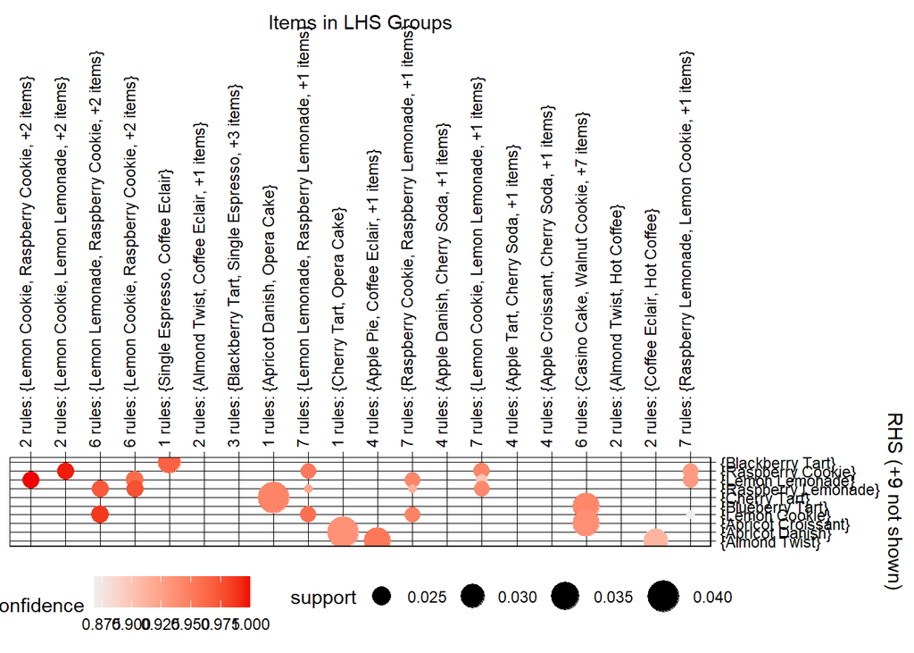

```r
# Create a parallel coordinates plot for the association rules
plot(rules_sorted,
     method = "paracoord",
     control = list(reorder = TRUE),  # Reorder the axes for better readability
     main = "Parallel Coordinates Plot of High-Confidence Rules")
```

#### Key Insights from the Parallel Coordinates Plot

##### Notable Patterns:

- **Strong Associations**: Items like **Raspberry Cookie**, **Raspberry Lemonade**, and **Lemon Lemonade** appear frequently on the left, connecting to multiple items on the right with strong confidence (indicated by dark red arrows). This suggests that these items are frequently purchased together, making them ideal for bundling or promotions.
- **Crossed Lines**: Several arrows cross paths, indicating complex relationships where multiple items on the LHS may lead to different RHS items. For example, **Hot Coffee** leads to various drinks and desserts, showing the flexibility of item pairings.
- **Thinner, Lighter Arrows**: Some items, like **Blackberry Tart** and **Almond Twist**, have thinner and lighter arrows, indicating weaker confidence in their associations. These items may still be related but are less reliable for predicting purchases of RHS items.

##### Strategic Insights:

**High-Confidence Rules**: Focus marketing efforts on items like **Raspberry Lemonade**, **Lemon Cookie**, and **Chocolate Tart**, which consistently appear in strong associations. Bundling these products or recommending them together can drive higher sales.

**Promotional Opportunities**: Items with weaker but still significant associations, such as **Hot Coffee** and **Cherry Soda**, could be targeted in specific promotions to increase the frequency of their purchase with other related items.

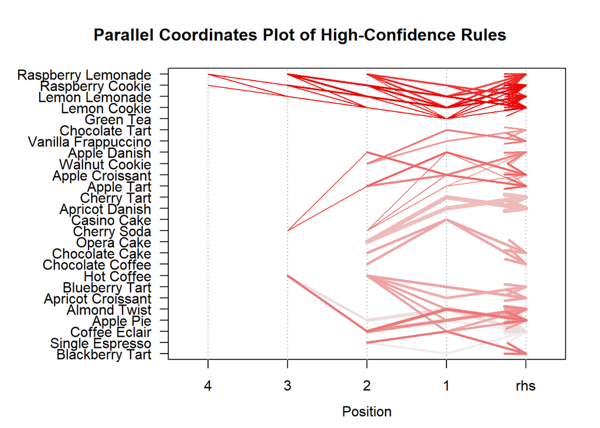

### 20,000 Transactions Dataset

In the analysis of the 20,000 transactions dataset, the Apriori algorithm was applied using a minimum support of 0.01 to identify frequent itemsets. The dataset, containing 50 unique items, was processed efficiently to generate 124 frequent itemsets, each appearing in at least 200 transactions. The algorithm effectively sorted and recoded the items, creating a transaction tree and examining subsets of size 1 to 5, leading to the discovery of meaningful patterns in customer purchasing behavior.

```r
tr20k <- read.transactions("tr-20k-canonical.csv", sep = ",")
frequent_item_sets_tr20k <- apriori(tr20k, parameter = list(support = 0.01, target = "frequent itemsets"))
```

```
Apriori

Parameter specification:
```

|  | confidence | minval | smax | arem | aval | originalSupport | maxtime | support | minlen | maxlen | target | ext |
| --- | --- | --- | --- | --- | --- | --- | --- | --- | --- | --- | --- | --- |
|  | NA | 0.1 | 1 | none | FALSE | TRUE | 5 | 0.01 | 1 | 10 | frequent itemsets | TRUE |

```
Algorithmic control:
```

|  | filter | tree | heap | memopt | load | sort | verbose |
| --- | --- | --- | --- | --- | --- | --- | --- |
|  | 0.1 | TRUE | TRUE | FALSE | TRUE | 2 | TRUE |

```
Absolute minimum support count: 200

set item appearances ...[0 item(s)] done [0.00s].
set transactions ...[50 item(s), 20000 transaction(s)] done [0.01s].
sorting and recoding items ... [50 item(s)] done [0.00s].
creating transaction tree ... done [0.01s].
checking subsets of size 1 2 3 4 5 done [0.01s].
sorting transactions ... done [0.00s].
writing ... [124 set(s)] done [0.00s].
creating S4 object  ... done [0.00s].
```

```r
rules_for_tr20k <- apriori(tr20k, parameter = list(support = 0.01, conf = 0.85, target = "rules"))
```

```
Apriori

Parameter specification:
```

|  | confidence | minval | smax | arem | aval | originalSupport | maxtime | support | minlen | maxlen | target | ext |
| --- | --- | --- | --- | --- | --- | --- | --- | --- | --- | --- | --- | --- |
|  | 0.85 | 0.1 | 1 | none | FALSE | TRUE | 5 | 0.01 | 1 | 10 | rules | TRUE |

```
Algorithmic control:
```

|  | filter | tree | heap | memopt | load | sort | verbose |
| --- | --- | --- | --- | --- | --- | --- | --- |
|  | 0.1 | TRUE | TRUE | FALSE | TRUE | 2 | TRUE |

```
Absolute minimum support count: 200

set item appearances ...[0 item(s)] done [0.00s].
set transactions ...[50 item(s), 20000 transaction(s)] done [0.02s].
sorting and recoding items ... [50 item(s)] done [0.00s].
creating transaction tree ... done [0.02s].
checking subsets of size 1 2 3 4 5 done [0.02s].
writing ... [78 rule(s)] done [0.00s].
creating S4 object  ... done [0.01s].
```

## Frequent Itemsets Analysis

```r
print(inspect(sort(frequent_item_sets_tr20k, decreasing = T, by="count")))
```

|  | items | support | count |
| --- | --- | --- | --- |
| [1] | {Coffee Eclair} | 0.10985 | 2197 |
| [2] | {Hot Coffee} | 0.10360 | 2072 |
| [3] | {Tuile Cookie} | 0.09865 | 1973 |
| [4] | {Apricot Danish} | 0.09270 | 1854 |
| [5] | {Orange Juice} | 0.09240 | 1848 |
| [6] | {Strawberry Cake} | 0.09200 | 1840 |
| [7] | {Gongolais Cookie} | 0.09185 | 1837 |
| [8] | {Cherry Tart} | 0.09125 | 1825 |
| [9] | {Marzipan Cookie} | 0.08645 | 1729 |
| [10] | {Lemon Cake} | 0.08600 | 1720 |

[output cut: 114 more lines]

```r
# Sort the frequent itemsets by count
frequent_item_sets <- sort(frequent_item_sets_tr20k, decreasing = TRUE, by = "count")

# Convert frequent itemsets to a data frame
frequent_itemsets_df <- as(frequent_item_sets, "data.frame")

# Select the top 10 frequent itemsets
top_frequent_itemsets <- head(frequent_itemsets_df, 10)

# Create a bar plot for the top frequent itemsets
ggplot(top_frequent_itemsets, aes(x = reorder(items, count), y = count)) +
  geom_bar(stat = "identity", fill = "steelblue") +
  coord_flip() +  # Flip the axes to make it more readable
  labs(title = "Top 10 Frequent Itemsets in 20,000 Transactions", x = "Itemsets", y = "Count") +
  theme_minimal()
```

#### Key Insights from Top 10 Frequent Itemsets in 20,000 Transactions

This chart highlights the most frequently purchased items from 20,000 transactions. **Coffee Eclair** and **Hot Coffee** are the top items, each appearing in over 2,000 transactions, suggesting strong customer demand for coffee-related products. Other popular items include **Tuile Cookie**, **Apricot Danish**, and **Orange Juice**, which are also highly purchased. These findings indicate that focusing promotions on these frequently bought items can drive further sales and boost customer engagement.

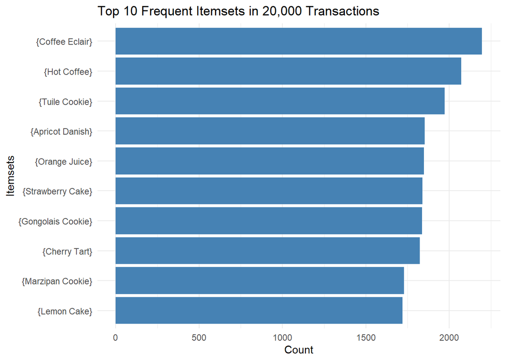

#### Association Rules Analysis

```r
print(inspect(sort(rules_for_tr20k, by="confidence")))
```

|  | lhs |  | rhs | support | confidence | coverage | lift | count |
| --- | --- | --- | --- | --- | --- | --- | --- | --- |
| [1] | {Green Tea, Lemon Cookie, Lemon Lemonade, Raspberry Cookie} | => | {Raspberry Lemonade} | 0.02040 | 1.0000000 | 0.02040 | 14.609204 | 408 |
| [2] | {Green Tea, Lemon Cookie, Raspberry Cookie, Raspberry Lemonade} | => | {Lemon Lemonade} | 0.02040 | 1.0000000 | 0.02040 | 15.026296 | 408 |
| [3] | {Almond Twist, Coffee Eclair, Hot Coffee} | => | {Apple Pie} | 0.02810 | 0.9982238 | 0.02815 | 13.462223 | 562 |
| [4] | {Green Tea, Raspberry Cookie, Raspberry Lemonade} | => | {Lemon Lemonade} | 0.02045 | 0.9975610 | 0.02050 | 14.989647 | 409 |
| [5] | {Green Tea, Lemon Cookie, Lemon Lemonade, Raspberry Lemonade} | => | {Raspberry Cookie} | 0.02040 | 0.9975550 | 0.02045 | 14.363643 | 408 |
| [6] | {Green Tea, Lemon Lemonade, Raspberry Cookie, Raspberry Lemonade} | => | {Lemon Cookie} | 0.02040 | 0.9975550 | 0.02045 | 14.616191 | 408 |
| [7] | {Apple Pie, Coffee Eclair, Hot Coffee} | => | {Almond Twist} | 0.02810 | 0.9964539 | 0.02820 | 13.622063 | 562 |
| [8] | {Lemon Cookie, Lemon Lemonade, Raspberry Cookie} | => | {Raspberry Lemonade} | 0.02545 | 0.9960861 | 0.02555 | 14.552025 | 509 |
| [9] | {Apple Danish, Apple Tart, Cherry Soda} | => | {Apple Croissant} | 0.02100 | 0.9952607 | 0.02110 | 14.017756 | 420 |
| [10] | {Green Tea, Lemon Lemonade, Raspberry Lemonade} | => | {Lemon Cookie} | 0.02045 | 0.9951338 | 0.02055 | 14.580715 | 409 |

[output cut: 68 more lines]

[output not shown]

```r
# Sort the rules by confidence
rules_sorted <- sort(rules_for_tr20k, by = "confidence", decreasing = TRUE)

# Create a scatter plot of rules with support on x-axis and confidence on y-axis
plot(rules_sorted,
     method = "scatterplot",
     measure = c("support", "confidence"),
     shading = "lift",  # Use lift as the color shading
     control = list(col = rev(heat.colors(100))),
     main = "Scatter Plot of Rules (Support vs Confidence) - Tr20k")
```

#### Key Insights from Scatter Plot of Rules (Support vs Confidence) - Tr20k

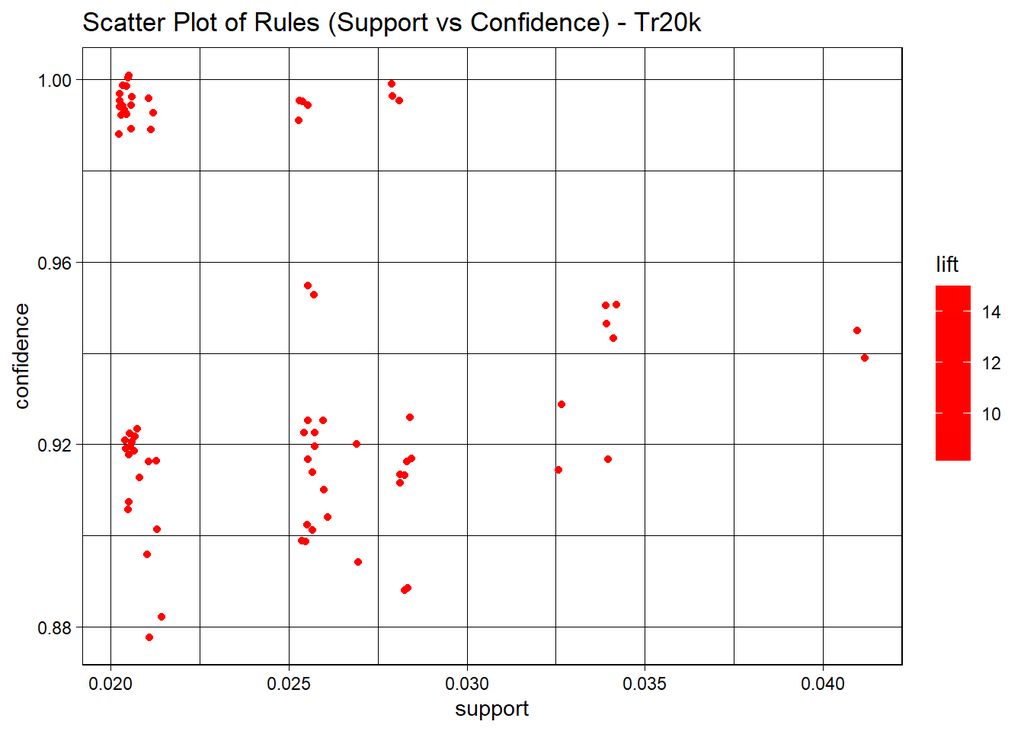

```r
# Create a grouped matrix plot to visualize the association rules
plot(rules_for_tr20k,
     method = "grouped",
     measure = "support",
     shading = "confidence",
     main = "Grouped Matrix of Association Rules")
```

#### Key Insights from Item Matrix Plot

This plot visualizes association rules between items in groups. Each bubble represents a rule, with the **size** indicating the **support** (frequency of the rule) and the **color intensity** representing the **confidence** (strength of the relationship between the items).

##### Strategic Implications:

Focus marketing efforts on items with high confidence and support, such as **Raspberry Cookie**, **Lemon Cookie**, and **Lemon Lemonade**, for bundling or promotions. Consider promoting items with moderate support, like **Apricot Danish** and **Raspberry Lemonade**, to increase their frequency in transactions.

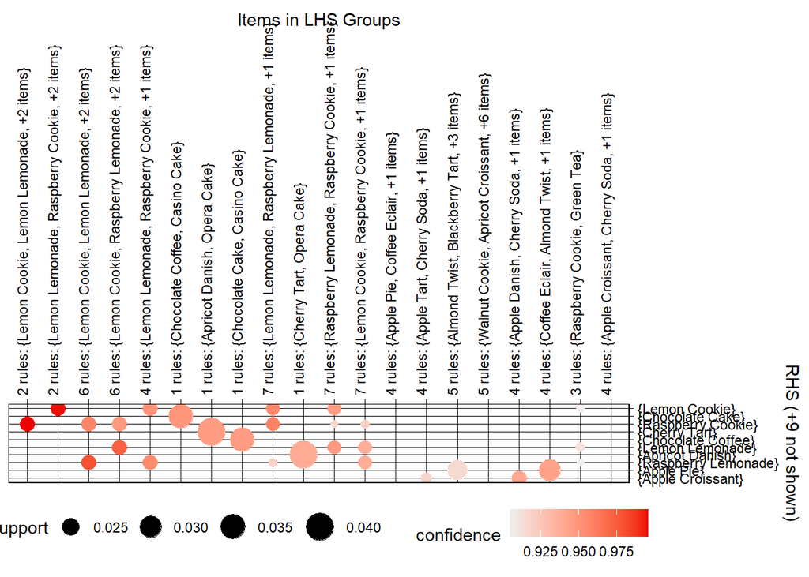

```r
# Create a parallel coordinates plot for the association rules
plot(rules_sorted,
     method = "paracoord",
     control = list(reorder = TRUE),  # Reorder the axes for better readability
     main = "Parallel Coordinates Plot of High-Confidence Rules - Tr20k")
```

#### Key Insights from the Parallel Coordinates Plot

##### Strategic Insights:

**High-Confidence Rules**: Focus on items like **Raspberry Lemonade**, **Raspberry Cookie**, and **Lemon Lemonade** for bundling strategies, as they consistently show strong associations with other products.

**Cross-Selling Opportunities**: Items with crossed connections, such as **Lemon Cookie** and **Hot Coffee**, indicate flexibility in their associations and can be recommended alongside multiple products to increase basket size.

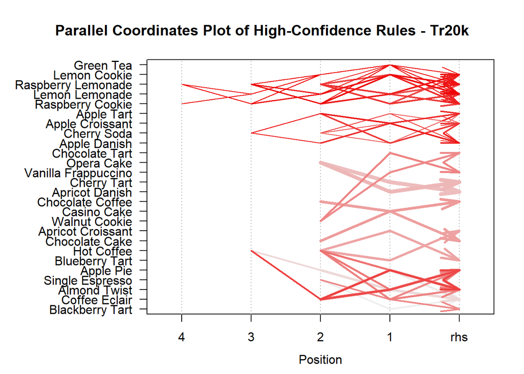

### 75,000 Transactions Dataset

For the 75,000 transactions dataset, the Apriori algorithm was applied with a minimum support of 0.01, generating 124 frequent itemsets. Each itemset appeared in at least 750 transactions, as specified by the support threshold. The dataset consisted of 50 unique items, and the algorithm efficiently processed the transactions, sorting and recoding the items before creating a transaction tree. Subsets of sizes 1 to 5 were examined, providing deeper insights into frequently purchased item combinations within the dataset.

```r
tr75k <- read.transactions("tr-75k-canonical.csv", sep = ",")
frequent_item_sets_tr75k <- apriori(tr75k, parameter = list(support = 0.01, target = "frequent itemsets"))
```

```
Apriori

Parameter specification:
```

|  | confidence | minval | smax | arem | aval | originalSupport | maxtime | support | minlen | maxlen | target | ext |
| --- | --- | --- | --- | --- | --- | --- | --- | --- | --- | --- | --- | --- |
|  | NA | 0.1 | 1 | none | FALSE | TRUE | 5 | 0.01 | 1 | 10 | frequent itemsets | TRUE |

```
Algorithmic control:
```

|  | filter | tree | heap | memopt | load | sort | verbose |
| --- | --- | --- | --- | --- | --- | --- | --- |
|  | 0.1 | TRUE | TRUE | FALSE | TRUE | 2 | TRUE |

```
Absolute minimum support count: 750

set item appearances ...[0 item(s)] done [0.00s].
set transactions ...[50 item(s), 75000 transaction(s)] done [0.03s].
sorting and recoding items ... [50 item(s)] done [0.00s].
creating transaction tree ... done [0.04s].
checking subsets of size 1 2 3 4 5 done [0.02s].
sorting transactions ... done [0.02s].
writing ... [124 set(s)] done [0.00s].
creating S4 object  ... done [0.01s].
```

```r
rules_for_tr75k <- apriori(tr75k, parameter = list(support = 0.01, conf = 0.85, target = "rules"))
```

```
Apriori

Parameter specification:
```

|  | confidence | minval | smax | arem | aval | originalSupport | maxtime | support | minlen | maxlen | target | ext |
| --- | --- | --- | --- | --- | --- | --- | --- | --- | --- | --- | --- | --- |
|  | 0.85 | 0.1 | 1 | none | FALSE | TRUE | 5 | 0.01 | 1 | 10 | rules | TRUE |

```
Algorithmic control:
```

|  | filter | tree | heap | memopt | load | sort | verbose |
| --- | --- | --- | --- | --- | --- | --- | --- |
|  | 0.1 | TRUE | TRUE | FALSE | TRUE | 2 | TRUE |

```
Absolute minimum support count: 750

set item appearances ...[0 item(s)] done [0.00s].
set transactions ...[50 item(s), 75000 transaction(s)] done [0.03s].
sorting and recoding items ... [50 item(s)] done [0.01s].
creating transaction tree ... done [0.07s].
checking subsets of size 1 2 3 4 5 done [0.02s].
writing ... [78 rule(s)] done [0.01s].
creating S4 object  ... done [0.01s].
```

## Frequent Itemsets Analysis

```r
print(inspect(sort(frequent_item_sets_tr75k, decreasing = T, by="count")))
```

|  | items | support | count |
| --- | --- | --- | --- |
| [1] | {Coffee Eclair} | 0.10924000 | 8193 |
| [2] | {Hot Coffee} | 0.10266667 | 7700 |
| [3] | {Tuile Cookie} | 0.10074667 | 7556 |
| [4] | {Cherry Tart} | 0.09316000 | 6987 |
| [5] | {Strawberry Cake} | 0.09264000 | 6948 |
| [6] | {Apricot Danish} | 0.09257333 | 6943 |
| [7] | {Orange Juice} | 0.09161333 | 6871 |
| [8] | {Gongolais Cookie} | 0.09044000 | 6783 |
| [9] | {Marzipan Cookie} | 0.08977333 | 6733 |
| [10] | {Berry Tart} | 0.08482667 | 6362 |

[output cut: 114 more lines]

```r
# Sort the frequent itemsets by count
frequent_item_sets <- sort(frequent_item_sets_tr75k, decreasing = TRUE, by = "count")

# Convert frequent itemsets to a data frame
frequent_itemsets_df <- as(frequent_item_sets, "data.frame")

# Select the top 10 frequent itemsets
top_frequent_itemsets <- head(frequent_itemsets_df, 10)

# Create a bar plot for the top frequent itemsets
ggplot(top_frequent_itemsets, aes(x = reorder(items, count), y = count)) +
  geom_bar(stat = "identity", fill = "steelblue") +
  coord_flip() +  # Flip the axes to make it more readable
  labs(title = "Top 10 Frequent Itemsets in 75,000 Transactions", x = "Itemsets", y = "Count") +
  theme_minimal()
```

#### Key Insights from Top 10 Frequent Itemsets in 75,000 Transactions

This chart displays the most frequently purchased items from 75,000 transactions. **Coffee Eclair** and **Hot Coffee** lead in popularity, each appearing in over 7,000 transactions, indicating strong customer demand for coffee-related products. Other highly frequent items include **Tuile Cookie**, **Cherry Tart**, and **Strawberry Cake**, which are frequently purchased as well. These findings highlight an opportunity to promote coffee and dessert pairings, capitalizing on the popularity of these items to drive further sales.

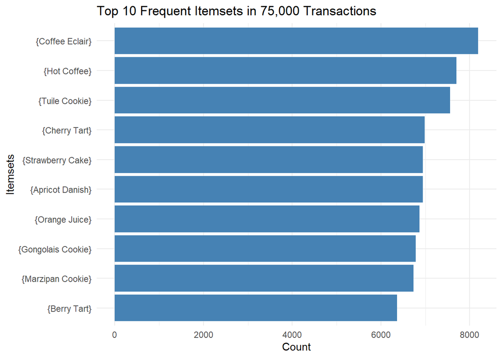

## Association Rules Analysis

```r
print(inspect(sort(rules_for_tr75k, by="confidence")))
```

|  | lhs |  | rhs | support | confidence | coverage | lift | count |
| --- | --- | --- | --- | --- | --- | --- | --- | --- |
| [1] | {Green Tea, Lemon Cookie, Raspberry Cookie, Raspberry Lemonade} | => | {Lemon Lemonade} | 0.02073333 | 1.0000000 | 0.02073333 | 14.654162 | 1555 |
| [2] | {Green Tea, Lemon Cookie, Lemon Lemonade, Raspberry Cookie} | => | {Raspberry Lemonade} | 0.02073333 | 1.0000000 | 0.02073333 | 14.760874 | 1555 |
| [3] | {Green Tea, Lemon Cookie, Lemon Lemonade, Raspberry Lemonade} | => | {Raspberry Cookie} | 0.02073333 | 1.0000000 | 0.02073333 | 14.784151 | 1555 |
| [4] | {Green Tea, Lemon Lemonade, Raspberry Cookie, Raspberry Lemonade} | => | {Lemon Cookie} | 0.02073333 | 0.9993573 | 0.02074667 | 14.693550 | 1555 |
| [5] | {Green Tea, Lemon Cookie, Raspberry Cookie} | => | {Raspberry Lemonade} | 0.02073333 | 0.9980745 | 0.02077333 | 14.732451 | 1555 |
| [6] | {Green Tea, Lemon Cookie, Raspberry Cookie} | => | {Lemon Lemonade} | 0.02073333 | 0.9980745 | 0.02077333 | 14.625945 | 1555 |
| [7] | {Green Tea, Lemon Lemonade, Raspberry Lemonade} | => | {Raspberry Cookie} | 0.02074667 | 0.9974359 | 0.02080000 | 14.746243 | 1556 |
| [8] | {Lemon Cookie, Lemon Lemonade, Raspberry Lemonade} | => | {Raspberry Cookie} | 0.02556000 | 0.9973985 | 0.02562667 | 14.745691 | 1917 |
| [9] | {Green Tea, Lemon Lemonade, Raspberry Lemonade} | => | {Lemon Cookie} | 0.02073333 | 0.9967949 | 0.02080000 | 14.655874 | 1555 |
| [10] | {Lemon Cookie, Raspberry Cookie, Raspberry Lemonade} | => | {Lemon Lemonade} | 0.02556000 | 0.9953271 | 0.02568000 | 14.585684 | 1917 |

[output cut: 68 more lines]

[output not shown]

```r
# Create a scatter plot of rules with support on x-axis and confidence on y-axis
plot(rules_sorted,
     method = "scatterplot",
     measure = c("support", "confidence"),
     shading = "lift",  # Use lift as the color shading
     control = list(col = rev(heat.colors(100)), jitter = 0),  # Disable jitter
     main = "Scatter Plot of Rules (Support vs Confidence) - Tr75k")
```

#### Key Insights from Scatter Plot of Rules (Support vs Confidence) - Tr75k

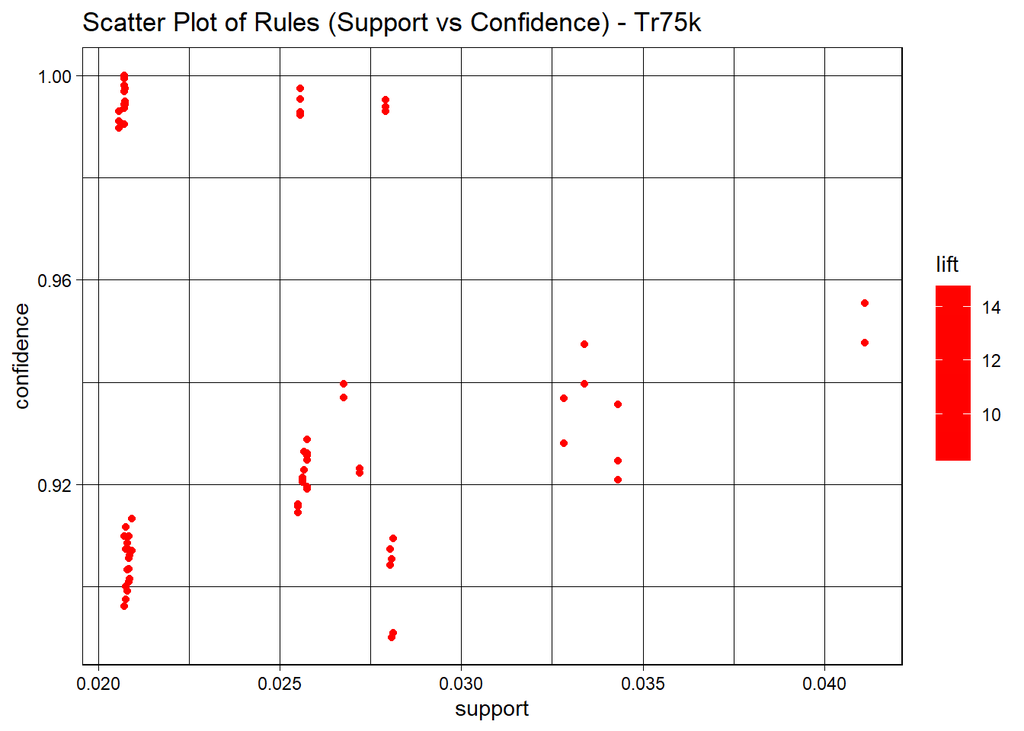

```r
# Create a grouped matrix plot to visualize the association rules
plot(rules_for_tr75k,
     method = "grouped",
     measure = "support",
     shading = "confidence",
     main = "Grouped Matrix of Association Rules")
```

#### Key Insights from Matrix Grouping

The data reveals several strong product combinations that can be leveraged for bundling and promotions:

- **Lemon Cookie, Lemon Lemonade, and Raspberry Cookie** are frequently purchased together, indicating a strong opportunity for bundling or pairing these items in promotions.
- **Raspberry Lemonade** is commonly associated with various desserts and drinks, suggesting it could be featured in cross-promotions with complementary products.
- **Walnut Cookie and Apricot Croissant** are moderately frequent combinations and could benefit from strategic placement together to encourage additional purchases.
- Items like **Cherry Soda** and **Apple Pie** appear less frequently together, indicating a potential niche opportunity for targeted promotions to increase their sales.

##### Actionable Takeaways:

Focus on promoting high-frequency combinations like **Lemon Cookie, Lemon Lemonade, and Raspberry Cookie**, while exploring cross-selling opportunities with **Raspberry Lemonade** and related items. Consider bundling moderately popular items like **Walnut Cookie** with other frequently purchased products to drive more sales.

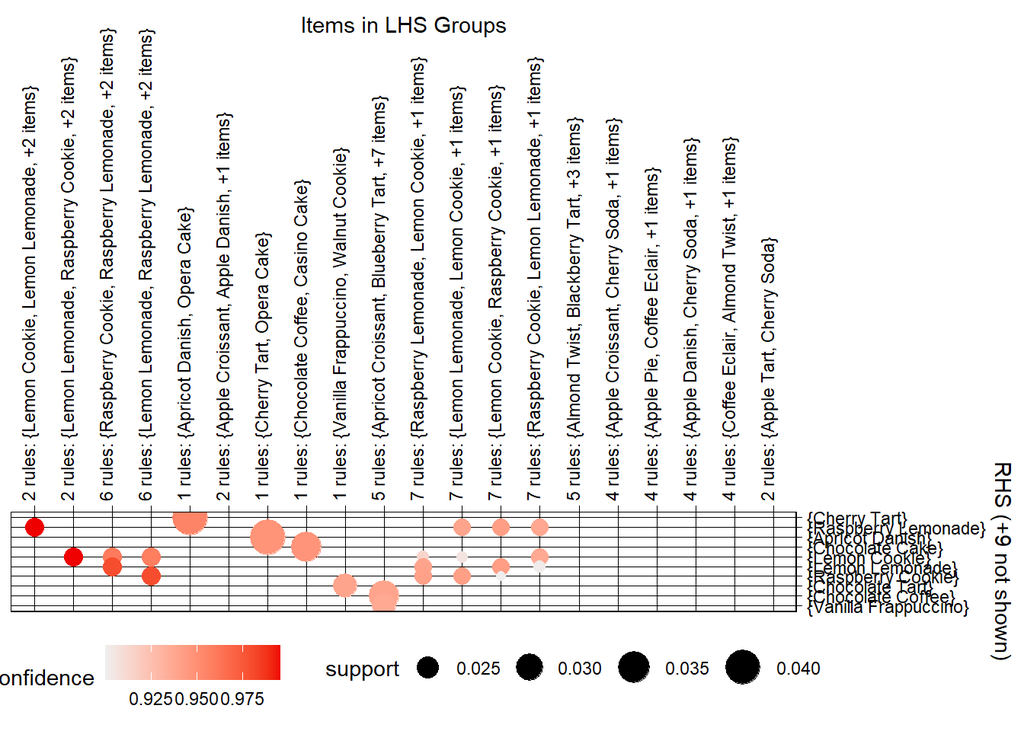

```r
# Created a parallel coordinates plot for the association rules
plot(rules_sorted,
     method = "paracoord",
     control = list(reorder = TRUE),  # Reorder the axes for better readability
     main = "Parallel Coordinates Plot of High-Confidence Rules - Tr75k")
```

#### Key Insights from High-Confidence Rules - Tr75k

**Raspberry Lemonade, Raspberry Cookie, and Lemon Cookie** frequently appear together with other desserts and beverages, making them ideal for cross-promotions or bundling strategies.

**Opera Cake, Apricot Danish, and Apricot Croissant** are popular pairings, indicating customer preference for these items in combination with others, presenting an opportunity to maximize sales through promotions.

**Hot Coffee and Raspberry Lemonade** show strong associations with multiple products, making them great candidates for highlighting in promotions or product recommendations.

Items like **Sinlge Espresso and Blueberry Tart** have weaker associations but could benefit from targeted marketing campaigns to increase their frequency in transactions.

##### Actionable Takeaways:

Leverage high-frequency combinations like **Raspberry Lemonade** and **Lemon Cookie** for bundling, while exploring opportunities to boost sales of less frequent items like **Almond Twist** through focused marketing strategies.

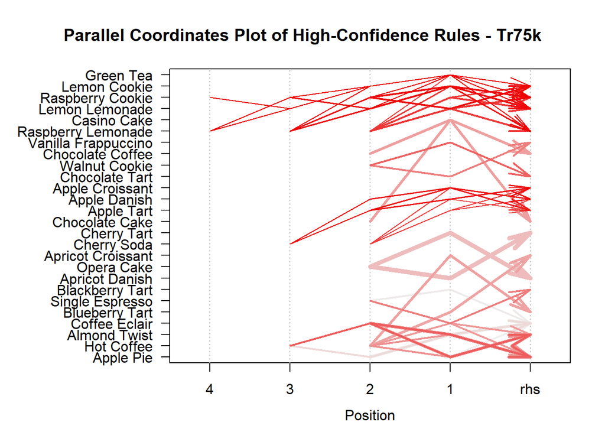

### Final Conclusions

The analysis of the bakery dataset using the Apriori algorithm has provided valuable insights into frequently purchased items and their associations. Items like **Raspberry Lemonade**, **Raspberry Cookie**, and **Lemon Cookie** consistently show strong relationships with other products, making them ideal candidates for bundling or promotional campaigns.

Key items such as **Coffee Eclair**, **Hot Coffee**, and **Tuile Cookie** appear frequently across all datasets, highlighting their popularity and the potential for cross-selling opportunities. On the other hand, niche products like **Almond Twist** and **Opera Cake** may benefit from targeted promotions to increase their frequency in transactions.

Overall, the insights derived from the association rule mining process allow businesses to strategically promote popular combinations, optimize product placement, and develop marketing campaigns that enhance customer engagement and drive sales.